# RMarkdown Assignment - Exercise 11 and 12

Pushkar Chougule

Oct 18th 2020

## R Markdown

**Reading the xlsx file into data frame. Using summary() and str() functions to understand data better and to understand the outliers**

```r
library(readxl)

housing_df1 <- read_excel("week-6-housing.xlsx")

summary(housing_df1)
```

```
##    Sale Date                     Sale Price       sale_reason
##  Min.   :2006-01-03 00:00:00   Min.   :    698   Min.   : 0.00
##  1st Qu.:2008-07-07 00:00:00   1st Qu.: 460000   1st Qu.: 1.00
##  Median :2011-11-17 00:00:00   Median : 593000   Median : 1.00
##  Mean   :2011-07-28 15:07:32   Mean   : 660738   Mean   : 1.55
##  3rd Qu.:2014-06-05 00:00:00   3rd Qu.: 750000   3rd Qu.: 1.00
##  Max.   :2016-12-16 00:00:00   Max.   :4400000   Max.   :19.00
##  sale_instrument  sale_warning         sitetype          addr_full
##  Min.   : 0.000   Length:12865       Length:12865       Length:12865
##  1st Qu.: 3.000   Class :character   Class :character   Class :character
##  Median : 3.000   Mode  :character   Mode  :character   Mode  :character
##  Mean   : 3.678
##  3rd Qu.: 3.000
##  Max.   :27.000
##       zip5         ctyname           postalctyn             lon
##  Min.   :98052   Length:12865       Length:12865       Min.   :-122.2
##  1st Qu.:98052   Class :character   Class :character   1st Qu.:-122.1
##  Median :98052   Mode  :character   Mode  :character   Median :-122.1
##  Mean   :98053                                         Mean   :-122.1
##  3rd Qu.:98053                                         3rd Qu.:-122.0
##  Max.   :98074                                         Max.   :-121.9
##       lat        building_grade  square_feet_total_living    bedrooms
##  Min.   :47.46   Min.   : 2.00   Min.   :  240            Min.   : 0.000
##  1st Qu.:47.67   1st Qu.: 8.00   1st Qu.: 1820            1st Qu.: 3.000
##  Median :47.69   Median : 8.00   Median : 2420            Median : 4.000
##  Mean   :47.68   Mean   : 8.24   Mean   : 2540            Mean   : 3.479
##  3rd Qu.:47.70   3rd Qu.: 9.00   3rd Qu.: 3110            3rd Qu.: 4.000
##  Max.   :47.73   Max.   :13.00   Max.   :13540            Max.   :11.000
##  bath_full_count  bath_half_count  bath_3qtr_count   year_built
##  Min.   : 0.000   Min.   :0.0000   Min.   :0.000   Min.   :1900
##  1st Qu.: 1.000   1st Qu.:0.0000   1st Qu.:0.000   1st Qu.:1979
##  Median : 2.000   Median :1.0000   Median :0.000   Median :1998
##  Mean   : 1.798   Mean   :0.6134   Mean   :0.494   Mean   :1993
##  3rd Qu.: 2.000   3rd Qu.:1.0000   3rd Qu.:1.000   3rd Qu.:2007
##  Max.   :23.000   Max.   :8.0000   Max.   :8.000   Max.   :2016
##  year_renovated    current_zoning       sq_ft_lot        prop_type
##  Min.   :   0.00   Length:12865       Min.   :    785   Length:12865
##  1st Qu.:   0.00   Class :character   1st Qu.:   5355   Class :character
##  Median :   0.00   Mode  :character   Median :   7965   Mode  :character
##  Mean   :  26.24                      Mean   :  22229
##  3rd Qu.:   0.00                      3rd Qu.:  12632
##  Max.   :2016.00                      Max.   :1631322
##   present_use
##  Min.   :  0.000
##  1st Qu.:  2.000
##  Median :  2.000
##  Mean   :  6.598
##  3rd Qu.:  2.000
##  Max.   :300.000
```

```r
str(housing_df1)
```

```
## tibble [12,865 x 24] (S3: tbl_df/tbl/data.frame)
##  $ Sale Date               : POSIXct[1:12865], format: "2006-01-03" "2006-01-03" ...
##  $ Sale Price              : num [1:12865] 698000 649990 572500 420000 369900 ...
##  $ sale_reason             : num [1:12865] 1 1 1 1 1 1 1 1 1 1 ...
##  $ sale_instrument         : num [1:12865] 3 3 3 3 3 15 3 3 3 3 ...
##  $ sale_warning            : chr [1:12865] NA NA NA NA ...
##  $ sitetype                : chr [1:12865] "R1" "R1" "R1" "R1" ...
##  $ addr_full               : chr [1:12865] "17021 NE 113TH CT" "11927 178TH PL NE" "13315 174TH AVE NE" "3303 178TH AVE NE" ...
##  $ zip5                    : num [1:12865] 98052 98052 98052 98052 98052 ...
##  $ ctyname                 : chr [1:12865] "REDMOND" "REDMOND" NA "REDMOND" ...
##  $ postalctyn              : chr [1:12865] "REDMOND" "REDMOND" "REDMOND" "REDMOND" ...
##  $ lon                     : num [1:12865] -122 -122 -122 -122 -122 ...
##  $ lat                     : num [1:12865] 47.7 47.7 47.7 47.6 47.7 ...
##  $ building_grade          : num [1:12865] 9 9 8 8 7 7 10 10 9 8 ...
##  $ square_feet_total_living: num [1:12865] 2810 2880 2770 1620 1440 4160 3960 3720 4160 2760 ...
##  $ bedrooms                : num [1:12865] 4 4 4 3 3 4 5 4 4 4 ...
##  $ bath_full_count         : num [1:12865] 2 2 1 1 1 2 3 2 2 1 ...
##  $ bath_half_count         : num [1:12865] 1 0 1 0 0 1 0 1 1 0 ...
##  $ bath_3qtr_count         : num [1:12865] 0 1 1 1 1 1 1 0 1 1 ...
##  $ year_built              : num [1:12865] 2003 2006 1987 1968 1980 ...
##  $ year_renovated          : num [1:12865] 0 0 0 0 0 0 0 0 0 0 ...
##  $ current_zoning          : chr [1:12865] "R4" "R4" "R6" "R4" ...
##  $ sq_ft_lot               : num [1:12865] 6635 5570 8444 9600 7526 ...
##  $ prop_type               : chr [1:12865] "R" "R" "R" "R" ...
##  $ present_use             : num [1:12865] 2 2 2 2 2 2 2 2 2 2 ...
```

**a. Data clean up task.**

**Answer a.**

> understanding above data and manually looking at excel data, determined possible outliers values and dropped them from dataframe

```r
housing_df <- housing_df1[housing_df1$`Sale Price` > 50000 & housing_df1$`Sale Price` < 3000000 & housing_df1$square_feet_total_living < 8000, ]

summary(housing_df)
```

```
##    Sale Date                     Sale Price       sale_reason
##  Min.   :2006-01-03 00:00:00   Min.   :  53502   Min.   : 0.000
##  1st Qu.:2008-07-10 00:00:00   1st Qu.: 460000   1st Qu.: 1.000
##  Median :2011-11-28 00:00:00   Median : 590000   Median : 1.000
##  Mean   :2011-08-04 06:20:00   Mean   : 633875   Mean   : 1.527
##  3rd Qu.:2014-06-16 00:00:00   3rd Qu.: 745000   3rd Qu.: 1.000
##  Max.   :2016-12-16 00:00:00   Max.   :2988000   Max.   :19.000
##  sale_instrument  sale_warning         sitetype          addr_full
##  Min.   : 0.000   Length:12672       Length:12672       Length:12672
##  1st Qu.: 3.000   Class :character   Class :character   Class :character
##  Median : 3.000   Mode  :character   Mode  :character   Mode  :character
##  Mean   : 3.611
##  3rd Qu.: 3.000
##  Max.   :27.000
##       zip5         ctyname           postalctyn             lon
##  Min.   :98052   Length:12672       Length:12672       Min.   :-122.2
##  1st Qu.:98052   Class :character   Class :character   1st Qu.:-122.1
##  Median :98052   Mode  :character   Mode  :character   Median :-122.1
##  Mean   :98053                                         Mean   :-122.1
##  3rd Qu.:98053                                         3rd Qu.:-122.0
##  Max.   :98074                                         Max.   :-121.9
##       lat        building_grade   square_feet_total_living    bedrooms
##  Min.   :47.46   Min.   : 2.000   Min.   : 240             Min.   : 0.000
##  1st Qu.:47.67   1st Qu.: 8.000   1st Qu.:1830             1st Qu.: 3.000
##  Median :47.69   Median : 8.000   Median :2420             Median : 4.000
##  Mean   :47.68   Mean   : 8.244   Mean   :2532             Mean   : 3.478
##  3rd Qu.:47.70   3rd Qu.: 9.000   3rd Qu.:3110             3rd Qu.: 4.000
##  Max.   :47.73   Max.   :13.000   Max.   :7980             Max.   :11.000
##  bath_full_count  bath_half_count  bath_3qtr_count    year_built
##  Min.   : 0.000   Min.   :0.0000   Min.   :0.0000   Min.   :1900
##  1st Qu.: 1.000   1st Qu.:0.0000   1st Qu.:0.0000   1st Qu.:1979
##  Median : 2.000   Median :1.0000   Median :0.0000   Median :1998
##  Mean   : 1.796   Mean   :0.6117   Mean   :0.4942   Mean   :1993
##  3rd Qu.: 2.000   3rd Qu.:1.0000   3rd Qu.:1.0000   3rd Qu.:2007
##  Max.   :23.000   Max.   :6.0000   Max.   :7.0000   Max.   :2016
##  year_renovated   current_zoning       sq_ft_lot        prop_type
##  Min.   :   0.0   Length:12672       Min.   :    785   Length:12672
##  1st Qu.:   0.0   Class :character   1st Qu.:   5400   Class :character
##  Median :   0.0   Mode  :character   Median :   7998   Mode  :character
##  Mean   :  25.7                      Mean   :  21533
##  3rd Qu.:   0.0                      3rd Qu.:  12600
##  Max.   :2016.0                      Max.   :1166246
##   present_use
##  Min.   :  0.000
##  1st Qu.:  2.000
##  Median :  2.000
##  Mean   :  6.501
##  3rd Qu.:  2.000
##  Max.   :300.000
```

```r
str(housing_df)
```

```
## tibble [12,672 x 24] (S3: tbl_df/tbl/data.frame)
##  $ Sale Date               : POSIXct[1:12672], format: "2006-01-03" "2006-01-03" ...
##  $ Sale Price              : num [1:12672] 698000 649990 572500 420000 369900 ...
##  $ sale_reason             : num [1:12672] 1 1 1 1 1 1 1 1 1 1 ...
##  $ sale_instrument         : num [1:12672] 3 3 3 3 3 15 3 3 3 3 ...
##  $ sale_warning            : chr [1:12672] NA NA NA NA ...
##  $ sitetype                : chr [1:12672] "R1" "R1" "R1" "R1" ...
##  $ addr_full               : chr [1:12672] "17021 NE 113TH CT" "11927 178TH PL NE" "13315 174TH AVE NE" "3303 178TH AVE NE" ...
##  $ zip5                    : num [1:12672] 98052 98052 98052 98052 98052 ...
##  $ ctyname                 : chr [1:12672] "REDMOND" "REDMOND" NA "REDMOND" ...
##  $ postalctyn              : chr [1:12672] "REDMOND" "REDMOND" "REDMOND" "REDMOND" ...
##  $ lon                     : num [1:12672] -122 -122 -122 -122 -122 ...
##  $ lat                     : num [1:12672] 47.7 47.7 47.7 47.6 47.7 ...
##  $ building_grade          : num [1:12672] 9 9 8 8 7 7 10 10 9 8 ...
##  $ square_feet_total_living: num [1:12672] 2810 2880 2770 1620 1440 4160 3960 3720 4160 2760 ...
##  $ bedrooms                : num [1:12672] 4 4 4 3 3 4 5 4 4 4 ...
##  $ bath_full_count         : num [1:12672] 2 2 1 1 1 2 3 2 2 1 ...
##  $ bath_half_count         : num [1:12672] 1 0 1 0 0 1 0 1 1 0 ...
##  $ bath_3qtr_count         : num [1:12672] 0 1 1 1 1 1 1 0 1 1 ...
##  $ year_built              : num [1:12672] 2003 2006 1987 1968 1980 ...
##  $ year_renovated          : num [1:12672] 0 0 0 0 0 0 0 0 0 0 ...
##  $ current_zoning          : chr [1:12672] "R4" "R4" "R6" "R4" ...
##  $ sq_ft_lot               : num [1:12672] 6635 5570 8444 9600 7526 ...
##  $ prop_type               : chr [1:12672] "R" "R" "R" "R" ...
##  $ present_use             : num [1:12672] 2 2 2 2 2 2 2 2 2 2 ...
```

**calculate R2 values for select few variables, to understand the potential predictor variables, which can have most impacts**

```r
cor(housing_df$"Sale Price", housing_df$sq_ft_lot)^2
```

```
## [1] 0.03459774
```

```r
cor(housing_df$"Sale Price", housing_df$square_feet_total_living)^2
```

```
## [1] 0.444824
```

```r
cor(housing_df$"Sale Price", housing_df$building_grade)^2
```

```
## [1] 0.3697124
```

```r
cor(housing_df$"Sale Price", housing_df$bedrooms)^2
```

```
## [1] 0.1096689
```

```r
cor(housing_df$"Sale Price", housing_df$bath_full_count)^2
```

```
## [1] 0.147803
```

```r
cor(housing_df$"Sale Price", housing_df$year_built)^2
```

```
## [1] 0.0686501
```

```r
#cor(housing_df$"Sale Price", housing_df$current_zoning)^2
#cor(housing_df$"Sale Price", housing_df$sitetype)^2
```

**b. Create two models : simple linear regression and multiple regression**

```r
housing_mod1 <- lm(`Sale Price` ~ sq_ft_lot, data = housing_df)

housing_mod2 <- lm(`Sale Price` ~ sq_ft_lot + square_feet_total_living + building_grade, data = housing_df)
```

**Answer b.** > For Multiple regression model, considered only few numeric variables, after looking at above R-squared (R2) values. square feet total living has 44.48% impact, building grade has 36.97% impact and used in addition to square feet lot variable.

**c. execute summary() function. explain R2 and adjusted R2 values**

```r
summary(housing_mod1)
```

```
##
## Call:
## lm(formula = `Sale Price` ~ sq_ft_lot, data = housing_df)
##
## Residuals:
##      Min       1Q   Median       3Q      Max
## -1257168  -166914   -38020   113408  2267970
##
## Coefficients:
##              Estimate Std. Error t value Pr(>|t|)
## (Intercept) 6.120e+05  2.647e+03  231.16   <2e-16 ***
## sq_ft_lot   1.017e+00  4.771e-02   21.31   <2e-16 ***
## ---
## Signif. codes:  0 '***' 0.001 '**' 0.01 '*' 0.05 '.' 0.1 ' ' 1
##
## Residual standard error: 274700 on 12670 degrees of freedom
## Multiple R-squared:  0.0346, Adjusted R-squared:  0.03452
## F-statistic: 454.1 on 1 and 12670 DF,  p-value: < 2.2e-16
```

```r
summary(housing_mod2)
```

```
##
## Call:
## lm(formula = `Sale Price` ~ sq_ft_lot + square_feet_total_living +
##     building_grade, data = housing_df)
##
## Residuals:
##      Min       1Q   Median       3Q      Max
## -1219650   -87492   -16387    64705  2068722
##
## Coefficients:
##                            Estimate Std. Error t value Pr(>|t|)
## (Intercept)              -2.550e+05  1.610e+04 -15.841  < 2e-16 ***
## sq_ft_lot                 2.561e-01  3.616e-02   7.083 1.48e-12 ***
## square_feet_total_living  1.390e+02  2.929e+00  47.450  < 2e-16 ***
## building_grade            6.448e+04  2.515e+03  25.642  < 2e-16 ***
## ---
## Signif. codes:  0 '***' 0.001 '**' 0.01 '*' 0.05 '.' 0.1 ' ' 1
##
## Residual standard error: 202800 on 12668 degrees of freedom
## Multiple R-squared:  0.4737, Adjusted R-squared:  0.4735
## F-statistic:  3800 on 3 and 12668 DF,  p-value: < 2.2e-16
```

**Answer c.**

> Simple linear regression model has R2 value of 0.0346 and adjusted R2 value of 0.03452, which is roughly about 3.46% of an impact on Sale Price. The difference between these two values is 0.00008 i.e. very minimal. SO, if the model were derived from the population rather than a sample and it would account for 0.0080% of variance, which is very small. Multiple linear regression model has R2 value of 0.4737 and adjusted R2 value of 0.4735, which is roughly about 47.37% of an impact on Sale Price. The difference between these two values is 0.0002 i.e. very minimal. SO, if the model were derived from the population rather than a sample and it would account for 0.02% of variance, which is very small. We can infer that the second model increased R2 value from 3.46% to 47.37%, which is very significant increase

**d. standardized betas function.**

```r
library(QuantPsyc)
lm.beta(housing_mod2)
```

```
##                sq_ft_lot square_feet_total_living           building_grade
##               0.04686682               0.46939216               0.24978199
```

**Answer d.**

> The standardized beta estimates tell us the number of standard deviations by which the outcome will change as a result of one standard deviation change in the predictor.

> With our cleaned up sample data 1 standard deviation of change in Square feet lot causes sales price to change by 0.04686682 standard deviation. 1 standard deviation change in square feet total living causes sales price to change by 0.46939216 standard deviation and 1 standard deviation change in building_grade can cause 0.24978199 standard deviation change in sale price.

**e. confidence interval**

```r
confint(housing_mod2, level = 0.95)
```

```
##                                  2.5 %        97.5 %
## (Intercept)              -2.865651e+05 -2.234570e+05
## sq_ft_lot                 1.852629e-01  3.270240e-01
## square_feet_total_living  1.332166e+02  1.446973e+02
## building_grade            5.954845e+04  6.940630e+04
```

**Answer e.**

> The confidence interval shows that there is positive relation between all the 3 predictors and outcome variable. Also the 95% confidence interval range for the 3 predictor variables is not very large / wide which indicates this cleaned up sample is fairly close representation of the beta values of the population. So, our model is closer to the real data.

**f. analysis of variance**

```r
anova(housing_mod1, housing_mod2)
```

|  | Res.Df | RSS | Df | Sum of Sq | F | Pr(>F) |
| --- | --- | --- | --- | --- | --- | --- |
| 1 | 12670 | 9.558864e+14 | NA | NA | NA | NA |
| 2 | 12668 | 5.211554e+14 | 2 | 4.347311e+14 | 5283.619 | 0 |

**Answer f.**

> The value in column labelled Pr(>F) is 2.2e−16 (i.e., 2.2 with the decimal place moved 16 places to the left, or a really very small value); we can say that housing_mod2 has significantly improved the fit of the model to the data compared to housing_mod1.

**g. casewise diagnostics**

**Answer g.**

> casewise diagnostics performed using the formuale given in (Field, Miles, and Field 2012) book, page 289

```r
housing_df$standardized.residuals <- rstandard(housing_mod2)
head(housing_df$standardized.residuals)
```

```
##           1           2           3           4           5           6
## -0.09591938 -0.37925188 -0.37167447 -0.33715111 -0.14031129 -2.91879468
```

```r
housing_df$studentized.residuals <- rstudent(housing_mod2)
head(housing_df$studentized.residuals)
```

```
##           1           2           3           4           5           6
## -0.09591563 -0.37923906 -0.37166183 -0.33713932 -0.14030586 -2.91966139
```

```r
housing_df$cooks.distance <- cooks.distance(housing_mod2)
head(housing_df$cooks.distance)
```

```
##            1            2            3            4            5            6
## 3.121938e-07 4.781441e-06 4.291748e-06 5.604655e-06 9.790214e-07 3.070981e-03
```

```r
housing_df$dfbeta <- dfbeta(housing_mod2)
head(housing_df$dfbeta)
```

```
##    (Intercept)     sq_ft_lot square_feet_total_living building_grade
## 1     8.956452  1.037009e-05             0.0006971453      -1.513854
## 2    32.268057  4.608331e-05             0.0015961445      -5.261074
## 3   -33.766324  4.129145e-05            -0.0066463149       5.307528
## 4    14.996795 -1.238558e-06             0.0104027413      -5.665371
## 5   -17.327262  1.582812e-06             0.0015801317       1.339939
## 6 -1295.144267  7.789333e-04            -0.3031042669     242.483553
```

```r
housing_df$dffit <- dffits(housing_mod2)
head(housing_df$dffit)
```

```
##            1            2            3            4            5            6
## -0.001117442 -0.004373154 -0.004143166 -0.004734665 -0.001978834 -0.110865779
```

```r
housing_df$leverage <- hatvalues(housing_mod2)
head(housing_df$leverage)
```

```
##            1            2            3            4            5            6
## 0.0001357102 0.0001329553 0.0001242553 0.0001971851 0.0001988752 0.0014398071
```

```r
housing_df$covariance.ratios <- covratio(housing_mod2)
head(housing_df$covariance.ratios)
```

```
##         1         2         3         4         5         6
## 1.0004487 1.0004034 1.0003965 1.0004772 1.0005086 0.9990661
```

**h. large standardized residuals**

**Answer h.**

> large standardized residuals calculated using the formula given in (Field, Miles, and Field 2012) book

```r
housing_df$large_residual <- housing_df$standardized.residuals > 2 | housing_df$standardized.residuals < -2
```

**i. sum of large standardized residuals**

**Answer i.**

> sum function to calculate sum of large standardized residuals

```r
sum(housing_df$large_residual)
```

```
## [1] 514
```

**j. specific variables with large standardized residuals**

**Answer j.**

> where large standardized residuals is TRUE

```r
housing_df[housing_df$large_residual, c("Sale Price", "sq_ft_lot", "square_feet_total_living", "building_grade" , "standardized.residuals")]
```

| Sale Price | sq_ft_lot | square_feet_total_living | building_grade | standardized.residuals |
| --- | --- | --- | --- | --- |
| 184667 | 7280 | 4160 | 7 | -2.918795 |
| 165000 | 278891 | 1850 | 9 | -2.413137 |
| 265000 | 112650 | 4920 | 10 | -4.129523 |
| 1392000 | 17291 | 3740 | 9 | 2.675408 |
| 148000 | 3430 | 1930 | 9 | -2.201026 |
| 1900000 | 37017 | 6610 | 11 | 2.554902 |
| 1520000 | 19173 | 4640 | 9 | 2.688114 |
| 1390000 | 225640 | 660 | 6 | 5.471517 |
| 1390000 | 225640 | 3280 | 10 | 2.401258 |
| 229000 | 236966 | 3840 | 10 | -3.725570 |

[output cut: 504 more lines]

**k. calculate leverage, cooks distance and covariance ratios and problematic cases**

```r
large_residuals <- housing_df[housing_df$large_residual, c("cooks.distance", "leverage", "covariance.ratios")]
head(large_residuals)
```

| cooks.distance | leverage | covariance.ratios |
| --- | --- | --- |
| 0.0030709812 | 0.0014398071 | 0.9990661 |
| 0.0039455256 | 0.0027028711 | 1.0011839 |
| 0.0030614879 | 0.0007175978 | 0.9956549 |
| 0.0004161391 | 0.0002324970 | 0.9982890 |
| 0.0004378059 | 0.0003613551 | 0.9991476 |
| 0.0027418219 | 0.0016773427 | 0.9999329 |

```r
#Check if any problematic cases exist, with cooks.distance greater than 1
cooks.distance.gt1.df <- housing_df[housing_df$cooks.distance > 1, ]

head(cooks.distance.gt1.df)
```

| Sale Date | Sale Price | sale_reason | sale_instrument | sale_warning | sitetype | addr_full | zip5 | ctyname | postalctyn | lon | lat | building_grade | square_feet_total_living | bedrooms | bath_full_count | bath_half_count | bath_3qtr_count | year_built | year_renovated | current_zoning | sq_ft_lot | prop_type | present_use | standardized.residuals | studentized.residuals | cooks.distance | dfbeta | dffit | leverage | … |
| --- | --- | --- | --- | --- | --- | --- | --- | --- | --- | --- | --- | --- | --- | --- | --- | --- | --- | --- | --- | --- | --- | --- | --- | --- | --- | --- | --- | --- | --- | --- |

**Answer k.**

> Looking at above, amongst 514 large residual instances, none of them has cooks.distance greater than 1. So, none of the cases us having any undue influence on the model.

```r
#average leverage calculations = (3 + 1) / 12672

avg_leverage <- (3 + 1) / 12672
avg_leverage
```

```
## [1] 0.0003156566
```

```r
# calculate twice the average leverage and thrice the average leverage values
avg_leverage_2 <- 2 * avg_leverage
avg_leverage_3 <- 3 * avg_leverage

nrow(large_residuals[large_residuals$leverage > avg_leverage_2,])
```

```
## [1] 216
```

```r
nrow(large_residuals[large_residuals$leverage > avg_leverage_3,])
```

```
## [1] 149
```

> we see that there are 216 large residuals cases with leverage greater than twice the average leverage and 149 large residuals cases with leverage greater than thrice the average leverage. however, none of the case has cooks distance greater than 1, as previously seen. So, we may not need to worry on this.

```r
cvr_upper <- 1 + avg_leverage_3
cvr_lower <- 1 - avg_leverage_3

cvr_lower
```

```
## [1] 0.999053
```

```r
cvr_upper
```

```
## [1] 1.000947
```

```r
nrow(large_residuals[large_residuals$covariance.ratios > cvr_upper | large_residuals$covariance.ratios < cvr_lower,])
```

```
## [1] 393
```

```r
nrow(large_residuals[large_residuals$covariance.ratios > cvr_upper,])
```

```
## [1] 20
```

```r
nrow(large_residuals[large_residuals$covariance.ratios < cvr_lower,])
```

```
## [1] 373
```

> we see that there are total of 393 large residuals cases with covariance ratio outside of lower limit of 0.999053 and upper limit of 1.000947. However, none of the case has cooks distance greater than 1, as previously seen. So, we may not need to worry on this.

**l. assumptions of independence**

```r
library(car)
dwt(housing_mod2)
```

```
##  lag Autocorrelation D-W Statistic p-value
##    1       0.4252643      1.149453       0
##  Alternative hypothesis: rho != 0
```

**Answer l.**

**m. assumptions of no multicolinearity**

```r
vif(housing_mod2)
```

```
##                sq_ft_lot square_feet_total_living           building_grade
##                 1.053607                 2.355268                 2.283872
```

```r
1/vif(housing_mod2)
```

```
##                sq_ft_lot square_feet_total_living           building_grade
##                0.9491204                0.4245801                0.4378528
```

```r
mean(vif(housing_mod2))
```

```
## [1] 1.897583
```

**Answer m.**

**n. plot() and hist() functions**

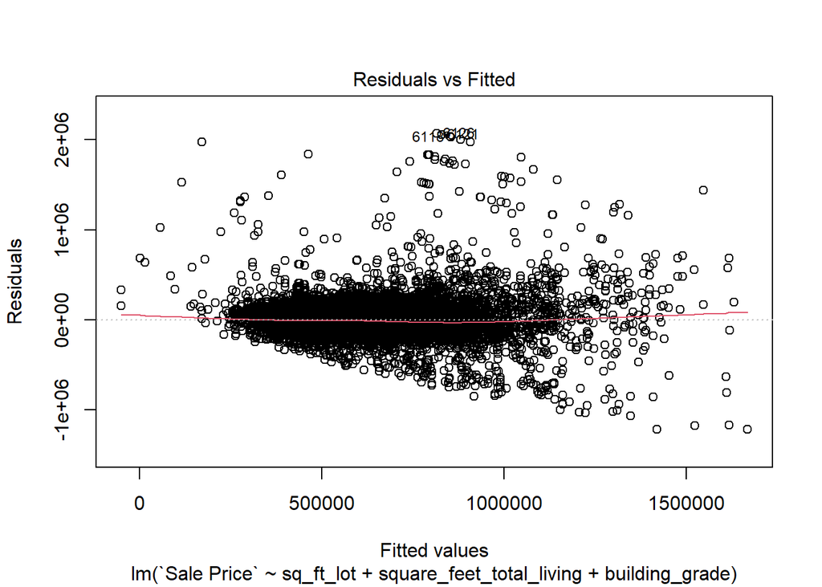

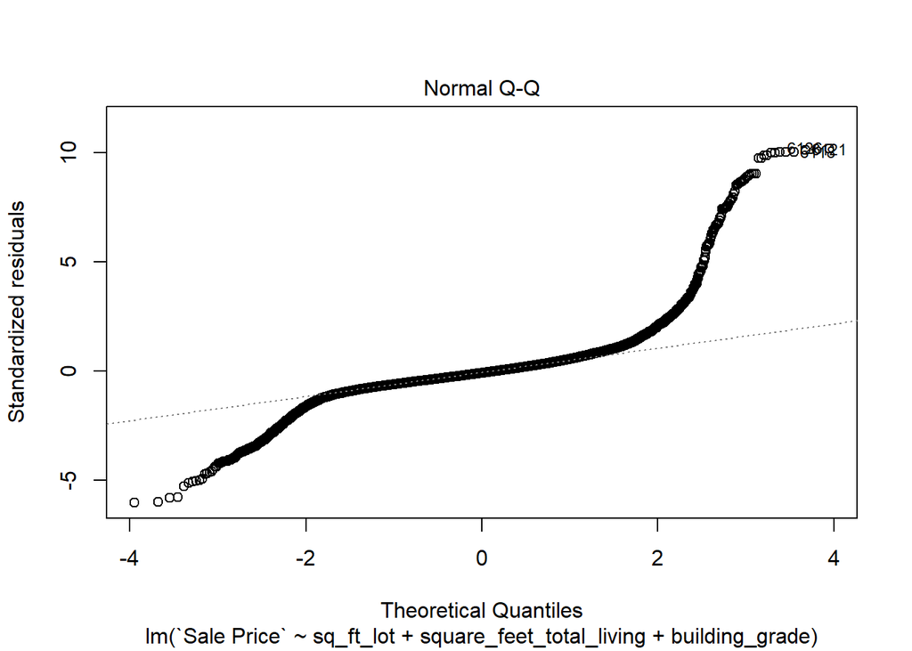

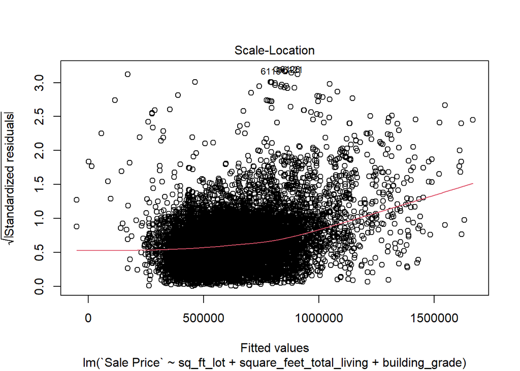

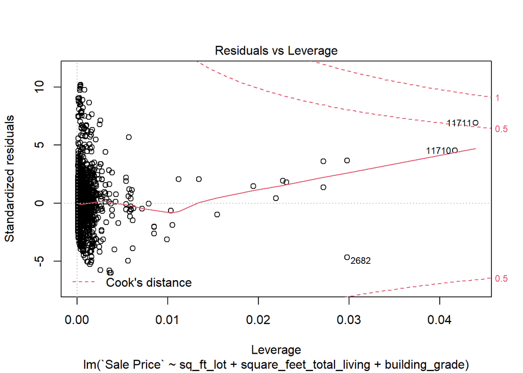

```r
plot(housing_mod2)
```

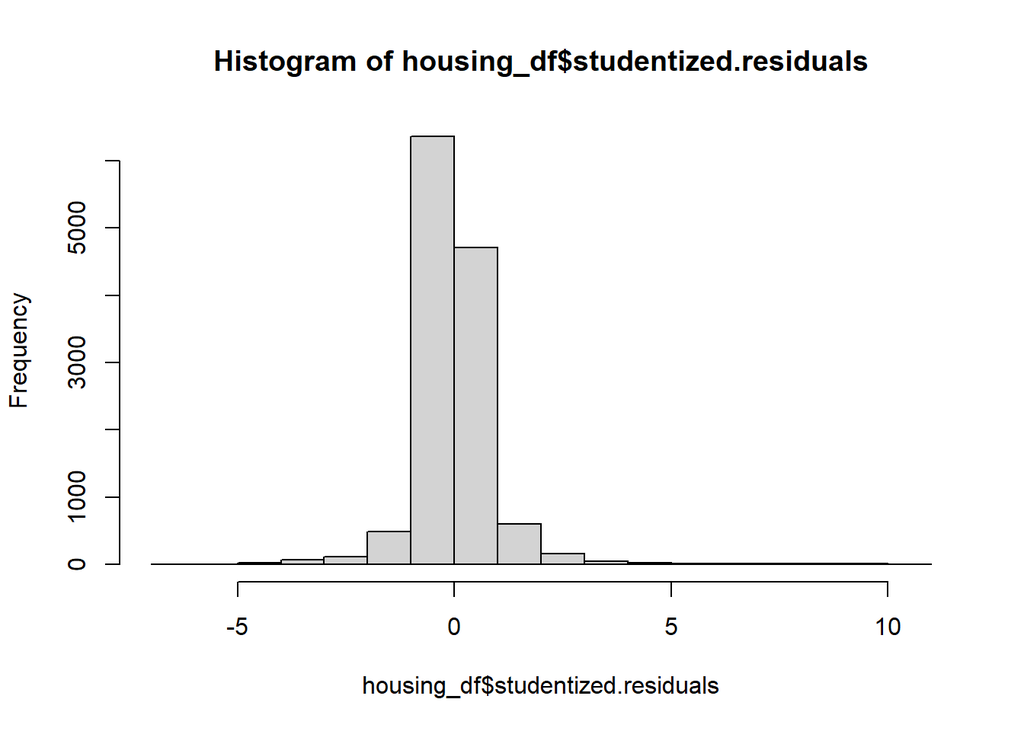

```r
hist(housing_df$studentized.residuals)
```

**Answer n.**

**o. unbiased regression model?**

**Answer o.**

## References

Field, A., J. Miles, and Z. Field. 2012. *Discovering Statistics Using R*. SAGE Publications. https://books.google.com/books?id=wd2K2zC3swIC.